# DATS 6101 - Google playstore apps

Name: Snehitha Tadapaneni, Sai Rachana Kandikattu, Amrutha Jayachandradhara, Wilona Nguyen, Pramod Krishnachari

2024-12-08

```r
# The package "ezids" (EZ Intro to Data Science) includes a lot of the helper functions we developed for the course.
# Importing the necessary libraries
library(ezids)
library(dplyr)
library(ggplot2)
library(DT)
library(corrplot)
library(lubridate)
library(tidyr)
library(scales)
library(cluster)
library(knitr)
library(kableExtra)
library(caret)
library(xgboost)
library(pROC)
```

# Introduction

Our research focuses on exploring the features of Size, installs, reviews,rating, Category, content rating, and Price on apps on Google Play Store and using different algorithms to identify the most influential attributes of highly installed apps on Google Play Store.

# Smart Question

“Which are the top 5 app categories, as identified by classification models (logistic regression,SVM, XGBoost, KNN, and random forest), that significantly influenced app success (measured by installs) based on app data from 2010 to 2018, and how accurately can these models predict success trends within this time period??”

# Loading the Dataset

```r
#Loading the Dataset
data_apps <- data.frame(read.csv("googleplaystore.csv"))
```

#### Description of the App Dataset Columns

1. App: The name of the application, represented as a character string.
2. Category: The main category of the app, such as “ART_AND_DESIGN,” represented as a character string.
3. Rating: The average user rating of the app, recorded as a numeric value.
4. Reviews: The total number of user reviews for the app, shown as a character string.
5. Size: The size of the application, represented as a character string.
6. Installs: The approximate number of installations for the app, stored as a character string.
7. Type: Indicates whether the app is free or paid, represented as a character string.
8. Price: The price of the app, stored as a character string. Free apps are listed as “0,” while paid apps have a dollar amount.
9. Content.Rating: The target age group for the app, represented as a character string.
10. Genres: The genre(s) of the app.
11. Last.Updated: The date of the app’s last update, stored as a character string.
12. Current.Ver: The current version of the app, represented as a character string.
13. Android.Ver: The minimum Android version required to run the app, stored as a character string.

# Summary of dataset after Data Cleaning

```r
#Dropping columns
data_apps <- data_apps[, !(colnames(data_apps) %in% c("Android.Ver", "Current.Ver", "Type", "App", "Genres"))]

##Price----

### Convertion of Price to numerical
data_apps$Price <- as.numeric(gsub("\\$", "", data_apps$Price)) #--Remove dollar symbols
missing_na <- is.na(data_apps$Price)
missing_blank <- data_apps$Price == ""
data_apps <- data_apps[!is.na(data_apps$Price) & data_apps$Price != "", ] #-- Remove price is NA or blank

## Size---

#### Replacing Missing values with the mean (Size)
# Replace "Varies with Device" in the Size column with NA
data_apps$Size[data_apps$Size == "Varies with device"] <- NA #"Varies with Device" to NA
data_apps <- data_apps[!grepl("\\+", data_apps$Size), ]
data_apps$Size <- ifelse(grepl("k", data_apps$Size),
                          as.numeric(gsub("k", "", data_apps$Size)) *
0.001,  # Convert "K" to MB
                          as.numeric(gsub("M", "", data_apps$Size))) # Remove "M" for megabytes

# Calculate and display the mean size for each category in the 'Type' column
mean_size_by_type <- tapply(data_apps$Size, data_apps$Category,
mean, na.rm = TRUE)

# Loop through each row and replace NA values in the Size column with the mean size of the corresponding category
data_apps$Size <- ifelse(is.na(data_apps$Size),  # Check if Size is NA
  round(mean_size_by_type[data_apps$Category], 1), # Replace with the mean size based on the Category
  data_apps$Size)  # Keep the original size if it's not NA


##Installs---

####Remove the '+' sign, Remove the commas, Convert to numeric
#clean installations
clean_installs <- function(Installs) {
  Installs <- gsub("\\+", "", Installs)
  Installs <- gsub(",", "", Installs)
  return(as.numeric(Installs))
}

data_apps$Installs <- sapply(data_apps$Installs, clean_installs)

nan_rows <- sapply(data_apps[, c("Size", "Installs")], function(x) any(is.nan(x)))

## Rating ---
data_apps <- data_apps %>%
  mutate(Rating = ifelse(is.na(Rating), mean(Rating, na.rm = TRUE), Rating))

# Identify the unique values in the 'Installs' column
unique_values <- unique(data_apps$Installs)

# Function to convert the installs to numeric
convert_to_numeric <- function(x) {
  # Remove non-numeric characters and convert to numeric
  as.numeric(gsub("[^0-9]", "", x)) * 10^(length(gregexpr(",", x)[[1]]) - 1)
}
# Sort unique values based on the custom numeric conversion
sorted_values <- unique_values[order(sapply(unique_values, convert_to_numeric))]

#Reviews---
data_apps$Reviews <- as.numeric(data_apps$Reviews)#Replace NA in Ratings with Overall Mean
data_apps <- data_apps %>%
  mutate(Rating = ifelse(is.na(Rating), mean(Rating, na.rm = TRUE), Rating))

#Content rating---
data_apps <- data_apps %>%
  mutate(
    Content.Rating = as.factor(Content.Rating)
  )
data_apps$Content.Rating <- as.numeric(data_apps$Content.Rating)
```

```r
#### Preprocessing for a model
#categories----
category_dummies <- model.matrix(~ Category - 1, data = data_apps)
colnames(category_dummies) <- gsub("Category", "cat", colnames(category_dummies))

# 3. Add dummy variables to the dataset and remove the original 'Category' column
data_apps <- cbind(data_apps, category_dummies)
data_apps$Category <- NULL

# 4. Replace spaces in column names with underscores
colnames(data_apps) <- gsub(" ", "_", colnames(data_apps))


#### Installs----
# Load necessary libraries
library(ggplot2)

# Create two categories: Low Installs and High Installs
# Calculate the median of Installs to split into two categories
median_installs <- median(data_apps$Installs, na.rm = TRUE)


#Reclassify into two categories
data_apps$Installs_Category <- ifelse(data_apps$Installs <= median_installs, "Low Installs", "High Installs")


# Convert 'Installs_Category' to factor with levels "Low Installs" and "High Installs"
data_apps$Installs_Category <- factor(data_apps$Installs_Category,
                                         levels = c("Low Installs", "High Installs"),
                                         labels = c(0, 1))


# Check the conversion
table(data_apps$Installs_Category)
```

```
##
##    0    1
## 5890 4950
```

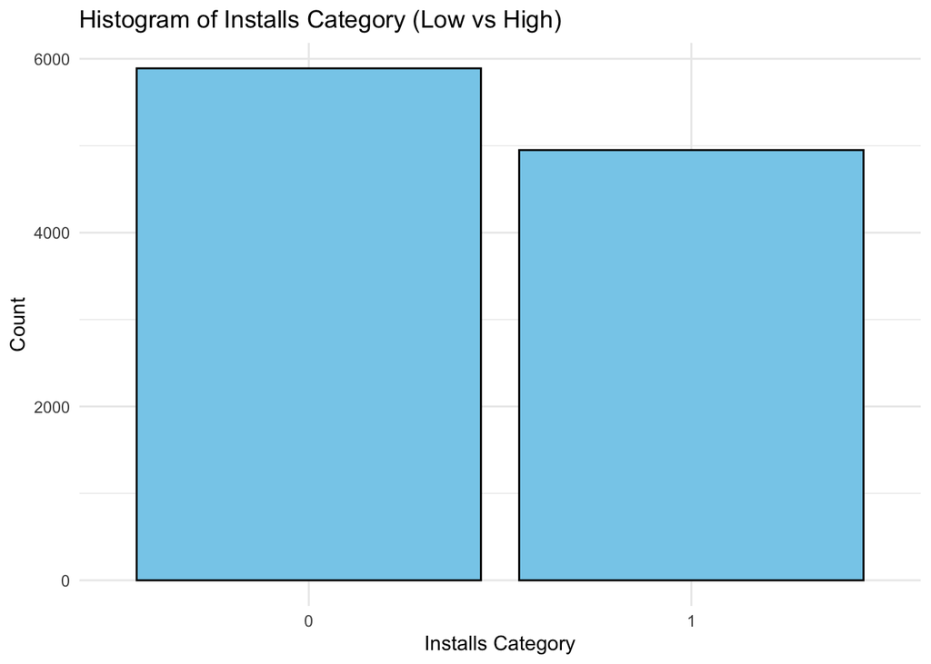

```r
# Create a histogram for the new categories
ggplot(data_apps, aes(x = Installs_Category)) +
  geom_bar(stat = "count", fill = "skyblue", color = "black") +
  labs(title = "Histogram of Installs Category (Low vs High)",
       x = "Installs Category",
       y = "Count") +
  theme_minimal()
```

```r
## Last updated----
# Convert the 'last_updated' column to Date type
data_apps$Last.Updated <- as.Date(data_apps$Last.Updated, format = "%B %d, %Y")

# Calculate the difference in days between the maximum date and each date in 'last_updated'
data_apps$Last.Updated <- as.numeric(difftime(max(data_apps$Last.Updated, na.rm = TRUE),
                                       data_apps$Last.Updated,
                                       units = "days"))
```

```r
# Display summary using kable
summary(data_apps) %>%
  kable(caption = "Summary of Google Play Store Apps") %>%
  kable_styling(bootstrap_options = "striped", full_width = FALSE) %>%
  scroll_box(width = "100%", height = "400px")
```

Summary of Google Play Store Apps

|  | Rating | Reviews | Size | Installs | Price | Content.Rating | Last.Updated | catART_AND_DESIGN | catAUTO_AND_VEHICLES | catBEAUTY | catBOOKS_AND_REFERENCE | catBUSINESS | catCOMICS | catCOMMUNICATION | catDATING | catEDUCATION | catENTERTAINMENT | catEVENTS | catFAMILY | catFINANCE | catFOOD_AND_DRINK | catGAME | catHEALTH_AND_FITNESS | catHOUSE_AND_HOME | catLIBRARIES_AND_DEMO | catLIFESTYLE | catMAPS_AND_NAVIGATION | catMEDICAL | catNEWS_AND_MAGAZINES | … |
| --- | --- | --- | --- | --- | --- | --- | --- | --- | --- | --- | --- | --- | --- | --- | --- | --- | --- | --- | --- | --- | --- | --- | --- | --- | --- | --- | --- | --- | --- | --- |
|  | Min. :1.000 | Min. : 0 | Min. : 0.0085 | Min. :0.000e+00 | Min. : 0.000 | Min. :1.000 | Min. : 0.0 | Min. :0.000000 | Min. :0.000000 | Min. :0.000000 | Min. :0.00000 | Min. :0.00000 | Min. :0.000000 | Min. :0.0000 | Min. :0.00000 | Min. :0.00000 | Min. :0.00000 | Min. :0.000000 | Min. :0.0000 | Min. :0.00000 | Min. :0.00000 | Min. :0.0000 | Min. :0.00000 | Min. :0.000000 | Min. :0.000000 | Min. :0.00000 | Min. :0.00000 | Min. :0.00000 | Min. :0.00000 | … |
|  | 1st Qu.:4.100 | 1st Qu.: 38 | 1st Qu.: 5.9000 | 1st Qu.:1.000e+03 | 1st Qu.: 0.000 | 1st Qu.:2.000 | 1st Qu.: 19.0 | 1st Qu.:0.000000 | 1st Qu.:0.000000 | 1st Qu.:0.000000 | 1st Qu.:0.00000 | 1st Qu.:0.00000 | 1st Qu.:0.000000 | 1st Qu.:0.0000 | 1st Qu.:0.00000 | 1st Qu.:0.00000 | 1st Qu.:0.00000 | 1st Qu.:0.000000 | 1st Qu.:0.0000 | 1st Qu.:0.00000 | 1st Qu.:0.00000 | 1st Qu.:0.0000 | 1st Qu.:0.00000 | 1st Qu.:0.000000 | 1st Qu.:0.000000 | 1st Qu.:0.00000 | 1st Qu.:0.00000 | 1st Qu.:0.00000 | 1st Qu.:0.00000 | … |
|  | Median :4.200 | Median : 2094 | Median : 14.5000 | Median :1.000e+05 | Median : 0.000 | Median :2.000 | Median : 76.0 | Median :0.000000 | Median :0.000000 | Median :0.000000 | Median :0.00000 | Median :0.00000 | Median :0.000000 | Median :0.0000 | Median :0.00000 | Median :0.00000 | Median :0.00000 | Median :0.000000 | Median :0.0000 | Median :0.00000 | Median :0.00000 | Median :0.0000 | Median :0.00000 | Median :0.000000 | Median :0.000000 | Median :0.00000 | Median :0.00000 | Median :0.00000 | Median :0.00000 | … |
|  | Mean :4.192 | Mean : 444153 | Mean : 21.2119 | Mean :1.546e+07 | Mean : 1.027 | Mean :2.465 | Mean : 259.7 | Mean :0.005996 | Mean :0.007841 | Mean :0.004889 | Mean :0.02131 | Mean :0.04244 | Mean :0.005535 | Mean :0.0357 | Mean :0.02159 | Mean :0.01439 | Mean :0.01375 | Mean :0.005904 | Mean :0.1819 | Mean :0.03376 | Mean :0.01172 | Mean :0.1055 | Mean :0.03146 | Mean :0.008118 | Mean :0.007841 | Mean :0.03524 | Mean :0.01264 | Mean :0.04271 | Mean :0.02611 | … |
|  | 3rd Qu.:4.500 | 3rd Qu.: 54776 | 3rd Qu.: 28.0000 | 3rd Qu.:5.000e+06 | 3rd Qu.: 0.000 | 3rd Qu.:2.000 | 3rd Qu.: 322.0 | 3rd Qu.:0.000000 | 3rd Qu.:0.000000 | 3rd Qu.:0.000000 | 3rd Qu.:0.00000 | 3rd Qu.:0.00000 | 3rd Qu.:0.000000 | 3rd Qu.:0.0000 | 3rd Qu.:0.00000 | 3rd Qu.:0.00000 | 3rd Qu.:0.00000 | 3rd Qu.:0.000000 | 3rd Qu.:0.0000 | 3rd Qu.:0.00000 | 3rd Qu.:0.00000 | 3rd Qu.:0.0000 | 3rd Qu.:0.00000 | 3rd Qu.:0.000000 | 3rd Qu.:0.000000 | 3rd Qu.:0.00000 | 3rd Qu.:0.00000 | 3rd Qu.:0.00000 | 3rd Qu.:0.00000 | … |
|  | Max. :5.000 | Max. :78158306 | Max. :100.0000 | Max. :1.000e+09 | Max. :400.000 | Max. :6.000 | Max. :3001.0 | Max. :1.000000 | Max. :1.000000 | Max. :1.000000 | Max. :1.00000 | Max. :1.00000 | Max. :1.000000 | Max. :1.0000 | Max. :1.00000 | Max. :1.00000 | Max. :1.00000 | Max. :1.000000 | Max. :1.0000 | Max. :1.00000 | Max. :1.00000 | Max. :1.0000 | Max. :1.00000 | Max. :1.000000 | Max. :1.000000 | Max. :1.00000 | Max. :1.00000 | Max. :1.00000 | Max. :1.00000 | … |

## Gradient Boosting

```r
#  Data Splitting -----------------------------------------------------

# Separate features (X) and target (y)
#X <- data_final %>% select(-Installs, -Success)
X <- data_apps %>% select(-Installs, -Installs_Category)  # Exclude the target variable
y <- data_apps$Installs_Category             # Extract the target variable


table(y)
```

```
## y
##    0    1
## 5890 4950
```

```r
#Split into training and testing sets
set.seed(123)
train_index <- createDataPartition(y, p = 0.7, list = FALSE)

# Define X_train, X_test, y_train, y_test
X_train <- X[train_index, ] %>% mutate(across(everything(), as.numeric))
X_test <- X[-train_index, ] %>% mutate(across(everything(), as.numeric))
y_train <- as.numeric(as.character(y[train_index]))  # Convert to numeric
y_test <- as.numeric(as.character(y[-train_index]))  # Convert to numeric
```

```r
# Convert data to matrix for XGBoost
dtrain <- xgb.DMatrix(data = as.matrix(X_train), label = y_train)
dtest <- xgb.DMatrix(data = as.matrix(X_test), label = y_test)

data_apps$Installs_Category <- factor(data_apps$Installs_Category, levels = c(0, 1))
```

```r
# 4. Train Gradient Boosting Model --------------------------------------

params <- list(
  objective = "binary:logistic",  # Binary classification
  eval_metric = "logloss",
  max_depth = 6,
  eta = 0.1,
  subsample = 0.8,
  colsample_bytree = 0.8
)

# Train the model
set.seed(42)
xgb_model <- xgb.train(
  params = params,
  data = dtrain,
  nrounds = 100,
  watchlist = list(train = dtrain, test = dtest),
  early_stopping_rounds = 10,
  verbose = 1
)
```

[output not shown]

```r
# 5. Model Evaluation ---------------------------------------------------

# Make predictions
y_pred <- predict(xgb_model, dtest)
y_pred_class <- ifelse(y_pred > 0.5, 1, 0)

# Confusion Matrix
y_pred_class <- factor(y_pred_class, levels = c(0, 1))
y_test <- factor(y_test, levels = c(0, 1))
conf_matrix <- confusionMatrix(y_pred_class, y_test)
print(conf_matrix)
```

```
## Confusion Matrix and Statistics
##
##           Reference
## Prediction    0    1
##          0 1702   71
##          1   65 1414
##
##                Accuracy : 0.9582
##                  95% CI : (0.9507, 0.9648)
##     No Information Rate : 0.5434
##     P-Value [Acc > NIR] : <2e-16
##
##                   Kappa : 0.9157
##
##  Mcnemar's Test P-Value : 0.6681
##
##             Sensitivity : 0.9632
##             Specificity : 0.9522
##          Pos Pred Value : 0.9600
##          Neg Pred Value : 0.9561
##              Prevalence : 0.5434
##          Detection Rate : 0.5234
##    Detection Prevalence : 0.5452
##       Balanced Accuracy : 0.9577
##
##        'Positive' Class : 0
##
```

Confusion Matrix:

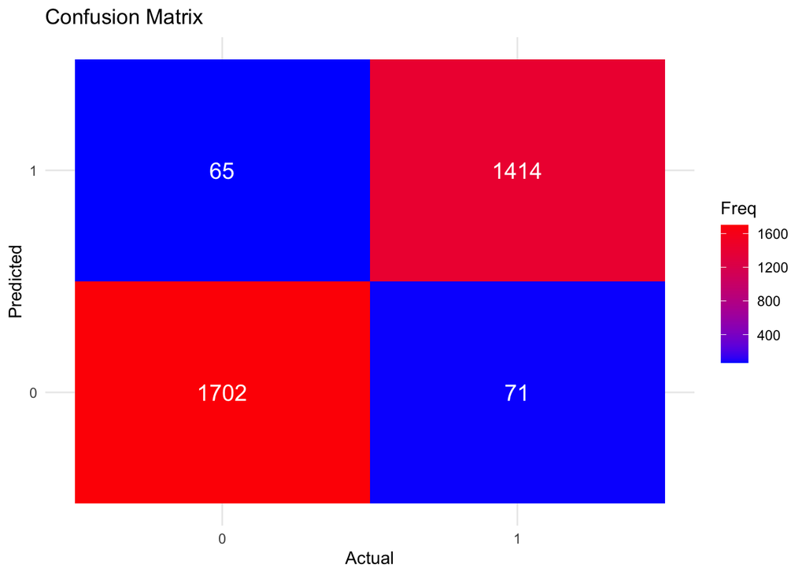

```r
# AUC and ROC Curve
roc_obj <- roc(as.numeric(as.character(y_test)), y_pred)
auc_value <- auc(roc_obj)
cat("AUC:", auc_value, "\n")
```

```
## AUC: 0.993948
```

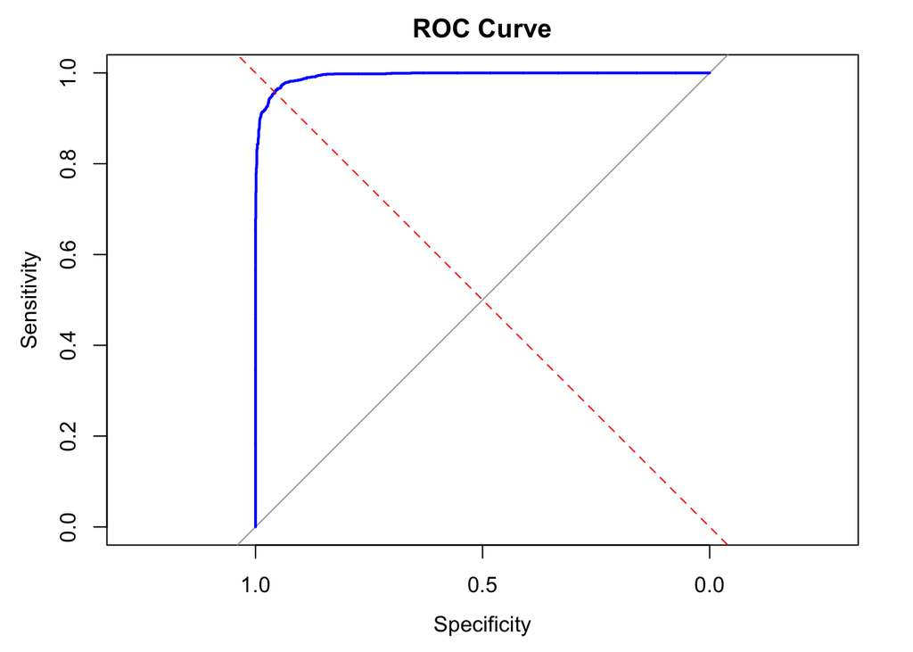

```r
# Plot ROC Curve
plot(roc_obj, main = "ROC Curve", col = "blue", lwd = 2)
abline(a = 0, b = 1, lty = 2, col = "red")
```

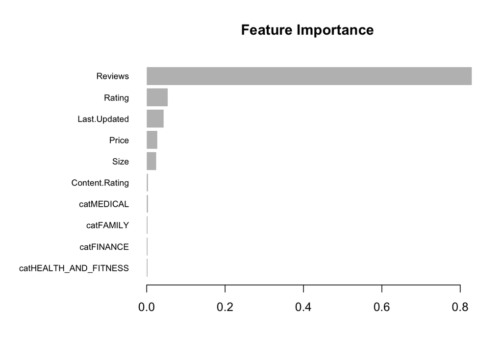

```r
# 6. Feature Importance -------------------------------------------------

importance_matrix <- xgb.importance(feature_names = colnames(X_train), model = xgb_model)
xgb.plot.importance(importance_matrix, top_n = 10, main = "Feature Importance")
```

```r
# 7. Save Model ---------------------------------------------------------

xgb.save(xgb_model, "xgb_app_success.model")
```

```
## [1] TRUE
```

```r
# Summary
cat("Gradient Boosting achieved an accuracy of", conf_matrix$overall["Accuracy"],
    "and AUC of", auc_value, "\n")
```

```
## Gradient Boosting achieved an accuracy of 0.9581796 and AUC of 0.993948
```

## Decision Tree

```r
# Remove the Installs and Installs numerical columns
data <- data_apps[, !colnames(data_apps) %in% c("Installs")]

# Split the data into training and testing sets
set.seed(123)  # Ensure reproducibility
trainIndex <- createDataPartition(data$Installs_Category, p = 0.8, list = FALSE)
trainData <- data[trainIndex, ]
testData <- data[-trainIndex, ]
```

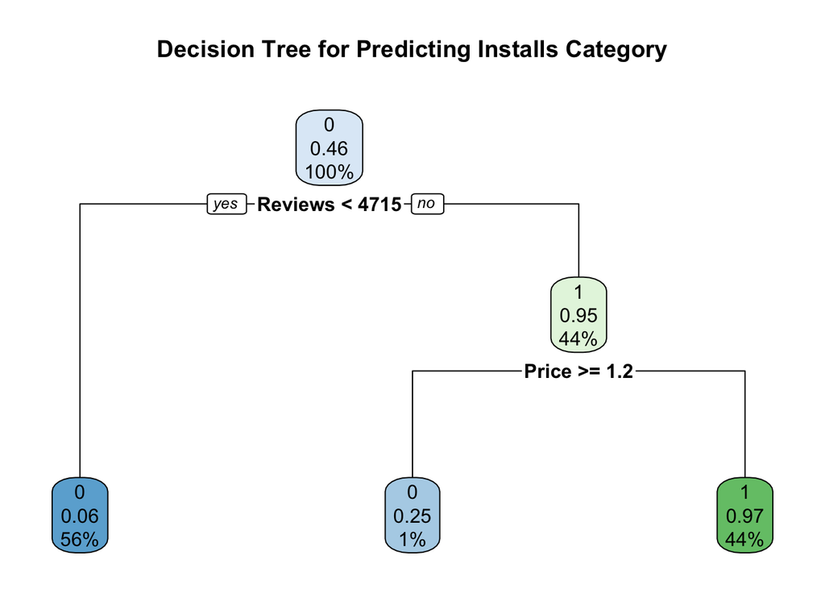

```r
# Load necessary libraries
library(rpart)
library(rpart.plot)

# Fit the decision tree model
set.seed(42)
tree_model <- rpart(
  Installs_Category ~ . ,
  data = trainData,
  method = "class"
)

# Plot the decision tree
rpart.plot(tree_model, main = "Decision Tree for Predicting Installs Category")
```

```r
# Predict on training and test datasets
train_predictions <- predict(tree_model, trainData, type = "class")
test_predictions <- predict(tree_model, testData, type = "class")



# Calculate accuracy
train_accuracy <- sum(train_predictions == trainData$Installs_Category) / nrow(trainData)
test_accuracy <- sum(test_predictions == testData$Installs_Category) / nrow(testData)

# Print accuracy results
cat("Training Accuracy: ", train_accuracy, "\n")
```

```
## Training Accuracy:  0.9519142
```

```r
cat("Test Accuracy: ", test_accuracy, "\n")
```

```
## Test Accuracy:  0.9488007
```

```r
# Check feature importance
importance <- tree_model$variable.importance

# Print feature importance
cat("Feature Importance:\n")
```

```
## Feature Importance:
```

```r
print(importance)
```

```
##        Reviews   Last.Updated         Rating           Size        catGAME
##     3432.80973      995.67498      847.08006      759.88064      369.26284
## Content.Rating          Price
##      360.36494       86.77665
```

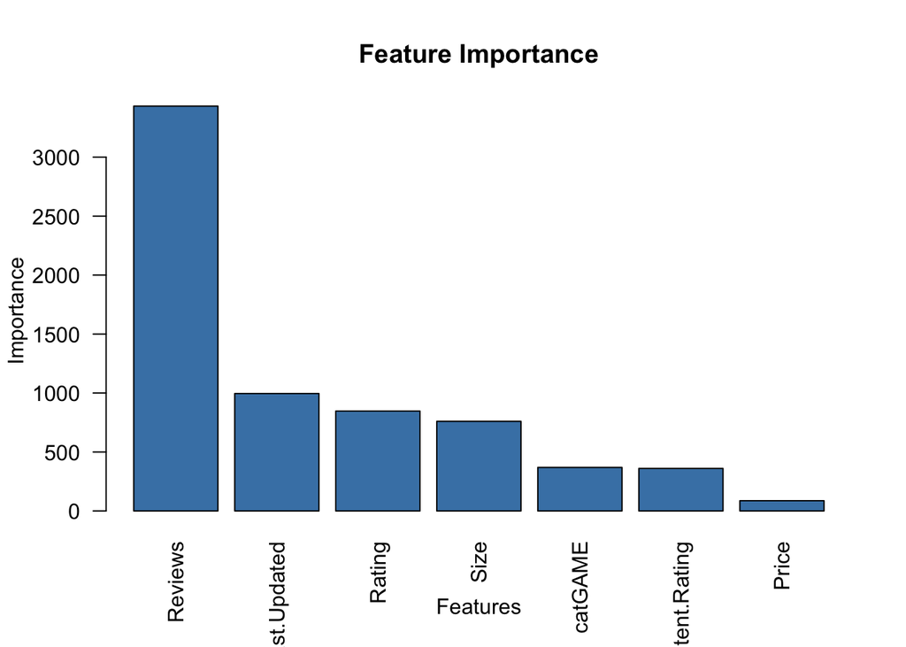

```r
# Visualize feature importance (optional)
barplot(
  importance,
  main = "Feature Importance",
  xlab = "Features",
  ylab = "Importance",
  col = "steelblue",
  las = 2
)
```

Why shift to Random Forest? High Dimensionality: With 41 variables, random forest handles many features better and can identify the most important ones. Feature Importance: Random forest provides a ranking of feature importance, helping us understand which variables influence the Installs_Category. Accuracy: Random forest generally has better predictive accuracy for larger and more complex datasets.

## Random Forest

#### Building Random FOrest Classifier

```r
library(randomForest)
library(caret)

# Train the random forest model
set.seed(123)
rf_model <- randomForest(Installs_Category ~ .,
                         data = trainData,
                         ntree = 500,       # Number of trees
                         mtry = 10,  # Number of predictors sampled at each split
                         importance = TRUE) # Enable importance calculation

# Print the model summary
print(rf_model)
```

```
##
## Call:
##  randomForest(formula = Installs_Category ~ ., data = trainData,      ntree = 500, mtry = 10, importance = TRUE)
##                Type of random forest: classification
##                      Number of trees: 500
## No. of variables tried at each split: 10
##
##         OOB estimate of  error rate: 4.02%
## Confusion matrix:
##      0    1 class.error
## 0 4554  158  0.03353141
## 1  191 3769  0.04823232
```

#### Plotting the Random Forest Result

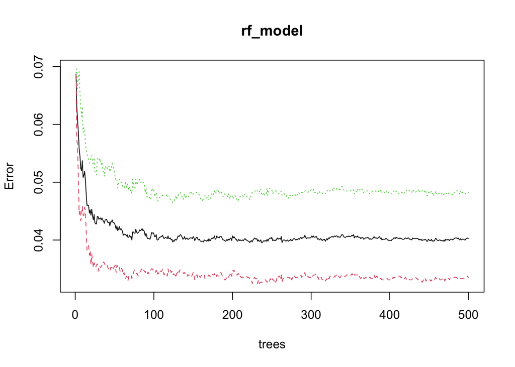

```r
plot(rf_model)
```

#### Testing the accuracy

```r
# Predictions on the training set
train_predictions <- predict(rf_model, trainData)

# Predictions on the testing set
test_predictions <- predict(rf_model, testData)


# Confusion Matrix for Training Data
 train_cm <- confusionMatrix(train_predictions, trainData$Installs_Category)
 print(train_cm)
```

```
## Confusion Matrix and Statistics
##
##           Reference
## Prediction    0    1
##          0 4699   19
##          1   13 3941
##
##                Accuracy : 0.9963
##                  95% CI : (0.9948, 0.9975)
##     No Information Rate : 0.5434
##     P-Value [Acc > NIR] : <2e-16
##
##                   Kappa : 0.9926
##
##  Mcnemar's Test P-Value : 0.3768
##
##             Sensitivity : 0.9972
##             Specificity : 0.9952
##          Pos Pred Value : 0.9960
##          Neg Pred Value : 0.9967
##              Prevalence : 0.5434
##          Detection Rate : 0.5419
##    Detection Prevalence : 0.5440
##       Balanced Accuracy : 0.9962
##
##        'Positive' Class : 0
##
```

```r
# Confusion Matrix for Testing Data
test_cm <- confusionMatrix(test_predictions, testData$Installs_Category)
print(test_cm)
```

```
## Confusion Matrix and Statistics
##
##           Reference
## Prediction    0    1
##          0 1139   49
##          1   39  941
##
##                Accuracy : 0.9594
##                  95% CI : (0.9502, 0.9673)
##     No Information Rate : 0.5434
##     P-Value [Acc > NIR] : <2e-16
##
##                   Kappa : 0.9181
##
##  Mcnemar's Test P-Value : 0.3374
##
##             Sensitivity : 0.9669
##             Specificity : 0.9505
##          Pos Pred Value : 0.9588
##          Neg Pred Value : 0.9602
##              Prevalence : 0.5434
##          Detection Rate : 0.5254
##    Detection Prevalence : 0.5480
##       Balanced Accuracy : 0.9587
##
##        'Positive' Class : 0
##
```

#### PLotting the Training, Testing and error Rate

[figure not shown]

```r
# Calculate training and testing accuracy
train_accuracy <- sum(train_predictions == trainData$Installs_Category) / nrow(trainData)
test_accuracy <- sum(test_predictions == testData$Install_Category) / nrow(testData)

# Prepare data for plotting
errors <- data.frame(
  Trees = 1:500,
  OOB = rf_model$err.rate[, 1],
  TrainAccuracy = rep(train_accuracy, 500),
  TestAccuracy = rep(test_accuracy, 500)
)

# Plot the errors
plot(errors$Trees, errors$OOB, type = "l", col = "blue", lwd = 2,
     ylim = c(0, 1), xlab = "Number of Trees", ylab = "Error/Accuracy",
     main = "Training, Testing, and OOB Error Rates")
lines(errors$Trees, 1 - errors$TrainAccuracy, col = "green", lwd = 2, lty = 2)  # Training error
lines(errors$Trees, 1 - errors$TestAccuracy, col = "red", lwd = 2, lty = 2)  # Testing error
legend("topright", legend = c("OOB Error", "Training Error", "Testing Error"),
       col = c("blue", "green", "red"), lwd = 2, lty = c(1, 2, 2))
```

#### Feature Importance Values

```r
# Variable importance
importance(rf_model)
```

```
##                                   0            1 MeanDecreaseAccuracy
## Rating                  16.45638823  20.45104941           23.5007339
## Reviews                188.99706937 356.34523950          295.5126394
## Size                    14.32775477  15.44908607           20.5100975
## Price                   53.71575255  52.84157810           67.0233652
## Content.Rating          10.95628575   8.18567671           13.0538565
## Last.Updated            16.86420254  19.55781604           26.6773422
## catART_AND_DESIGN       -2.13163306   1.06875961           -1.1842026
## catAUTO_AND_VEHICLES    -0.30502968   6.72680841            5.4091223
## catBEAUTY                1.35843078   3.67364807            3.3793096
## catBOOKS_AND_REFERENCE  -1.90856349   4.75649001            2.3529042
## catBUSINESS              0.79224656   4.78557827            5.4156598
## catCOMICS                2.90556805   2.65087336            4.1465436
## catCOMMUNICATION        -0.59869160  -1.47830468           -1.5030063
## catDATING                6.36968014   3.80001426            7.7918455
## catEDUCATION             9.71632248   7.05307468           11.4683096
## catENTERTAINMENT         9.72265282  -0.87141643            9.7756922
## catEVENTS                6.49065762   6.61375624            8.1561788
## catFAMILY               -5.97736336   6.09388118            2.7940075
## catFINANCE               8.21093932   3.50373643            7.8854030
## catFOOD_AND_DRINK       -4.10253558   2.49326550           -1.5290464
## catGAME                  7.44772580  -0.07257041            7.5953337
## catHEALTH_AND_FITNESS    5.16328525   5.00898520            7.3478415
## catHOUSE_AND_HOME       -1.00429132   2.52543547            0.9065160
## catLIBRARIES_AND_DEMO   -1.19842536   2.07066827            0.2888923
## catLIFESTYLE            -2.96935175   1.40206279           -1.2077481
## catMAPS_AND_NAVIGATION  -2.81526923   1.13746943           -1.0872827
## catMEDICAL               4.40760703  15.98034316           16.3343056
## catNEWS_AND_MAGAZINES   -0.06053466   4.47951514            3.0032858
## catPARENTING            -3.78953235   3.48670713           -0.5240984
## catPERSONALIZATION      -1.71381963   3.04906690            1.2774615
## catPHOTOGRAPHY          12.78364149   2.93662296           13.3158911
## catPRODUCTIVITY          4.14490954  -0.64148236            2.3486884
## catSHOPPING              3.38579300   2.26699782            3.9767072
## catSOCIAL                1.31683023   1.28209666            1.8385171
## catSPORTS               -0.78485647  -1.15798307           -1.3588361
## catTOOLS                 0.18275108   0.62963088            0.6816521
## catTRAVEL_AND_LOCAL     -0.76577774   0.04929191           -0.5140988
## catVIDEO_PLAYERS         2.57999992   1.38684589            2.8521703
## catWEATHER              -0.96955840  -4.06232993           -3.3440129
```

[output cut: 25 more lines]

```
## catLIFESTYLE                   5.157185
## catMAPS_AND_NAVIGATION         1.350171
## catMEDICAL                    28.846759
## catNEWS_AND_MAGAZINES          3.984587
## catPARENTING                   1.695279
## catPERSONALIZATION             4.348832
## catPHOTOGRAPHY                12.868394
## catPRODUCTIVITY                4.955689
## catSHOPPING                    3.766935
## catSOCIAL                      3.616154
## catSPORTS                      3.595892
## catTOOLS                       8.515779
## catTRAVEL_AND_LOCAL            2.244626
## catVIDEO_PLAYERS               3.447970
## catWEATHER                     2.282605
```

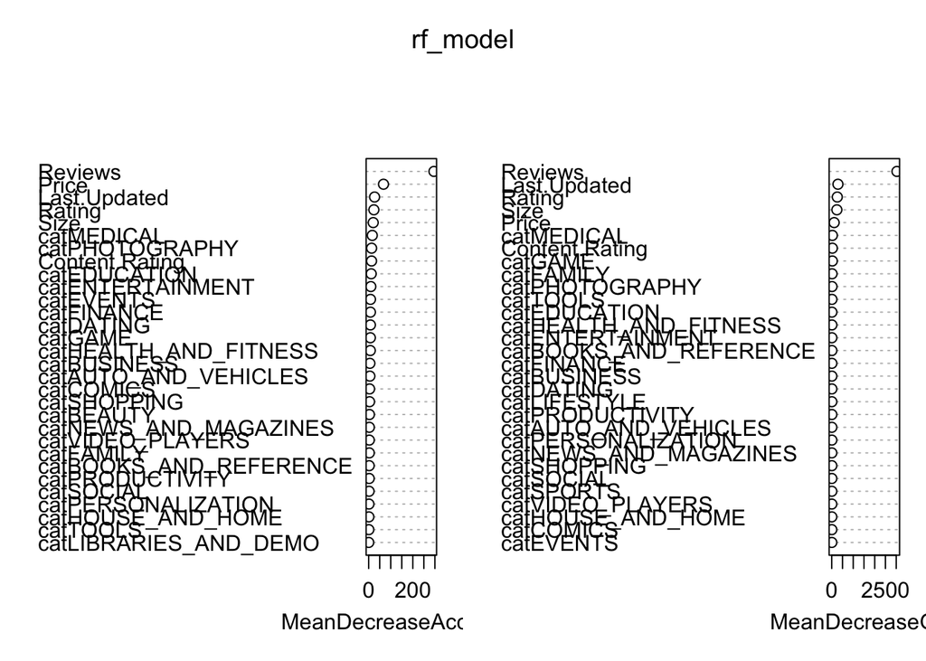

```r
# Plot variable importance
varImpPlot(rf_model)
```

#### Visualization for Feature Importance

```r
# Extract importance values
importance_values <- importance(rf_model)
importance_df <- data.frame(
  Feature = rownames(importance_values),
  MeanDecreaseAccuracy = importance_values[, "MeanDecreaseAccuracy"],
  MeanDecreaseGini = importance_values[, "MeanDecreaseGini"]
)
```

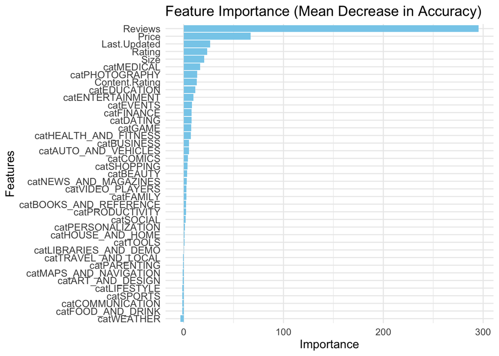

```r
# Plot Mean Decrease in Accuracy
accuracy_plot <- ggplot(importance_df, aes(x = reorder(Feature, MeanDecreaseAccuracy), y = MeanDecreaseAccuracy)) +
  geom_bar(stat = "identity", fill = "skyblue") +
  coord_flip() +
  labs(
    title = "Feature Importance (Mean Decrease in Accuracy)",
    x = "Features",
    y = "Importance"
  ) +
  theme_minimal() +
  theme(text = element_text(size = 12), axis.text.y = element_text(size = 10))

# Plot the accuracy plot
print(accuracy_plot)
```

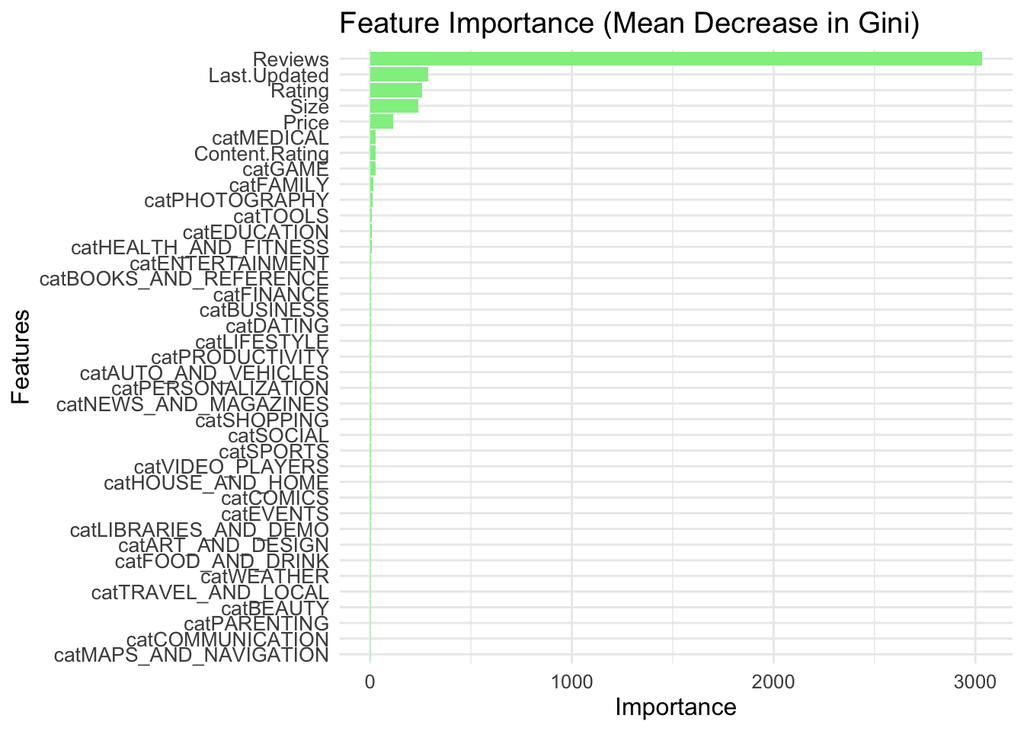

```r
# Save the plot with larger dimensions
#ggsave("feature_importance_accuracy_large.png", plot = accuracy_plot, width = 12, height = 10, dpi = 300)

# Plot Mean Decrease in Gini
gini_plot <- ggplot(importance_df, aes(x = reorder(Feature, MeanDecreaseGini), y = MeanDecreaseGini)) +
  geom_bar(stat = "identity", fill = "lightgreen") +
  coord_flip() +
  labs(
    title = "Feature Importance (Mean Decrease in Gini)",
    x = "Features",
    y = "Importance"
  ) +
  theme_minimal() +
  theme(text = element_text(size = 12), axis.text.y = element_text(size = 10))

# Plot the gini index plot
print(gini_plot)
```

```r
# Save the plot with larger dimensions
#ggsave("feature_importance_gini_large.png", plot = gini_plot, width = 12, height = 10, dpi = 300)
```

## SVM

```r
# Convert target variable to a factor
y <- as.factor(data_apps$Installs_Category)

# Remove unused columns
X <- data_apps[, !names(data_apps) %in% c('Installs', 'Installs_Category', 'Installs_Num')]

# Split data into training and testing sets
set.seed(42)
trainIndex <- createDataPartition(y, p = 0.75, list = FALSE)
X_train <- X[trainIndex, ]
X_test <- X[-trainIndex, ]
y_train <- y[trainIndex]
y_test <- y[-trainIndex]
str(X_train)
```

```
## 'data.frame':    8131 obs. of  39 variables:
##  $ Rating                : num  4.1 3.9 4.3 4.4 3.8 4.1 4.4 4.7 4.4 4.2 ...
##  $ Reviews               : num  159 967 967 167 178 ...
##  $ Size                  : num  19 14 2.8 5.6 19 29 33 3.1 12 20 ...
##  $ Price                 : num  0 0 0 0 0 0 0 0 0 0 ...
##  $ Content.Rating        : num  2 2 2 2 2 2 2 2 2 5 ...
##  $ Last.Updated          : num  213 205 49 500 104 55 322 36 8 128 ...
##  $ catART_AND_DESIGN     : num  1 1 1 1 1 1 1 1 1 1 ...
##  $ catAUTO_AND_VEHICLES  : num  0 0 0 0 0 0 0 0 0 0 ...
##  $ catBEAUTY             : num  0 0 0 0 0 0 0 0 0 0 ...
##  $ catBOOKS_AND_REFERENCE: num  0 0 0 0 0 0 0 0 0 0 ...
##  $ catBUSINESS           : num  0 0 0 0 0 0 0 0 0 0 ...
##  $ catCOMICS             : num  0 0 0 0 0 0 0 0 0 0 ...
##  $ catCOMMUNICATION      : num  0 0 0 0 0 0 0 0 0 0 ...
##  $ catDATING             : num  0 0 0 0 0 0 0 0 0 0 ...
```

[output cut: 25 more lines]

### Checking if the boundary is non-linear or linear

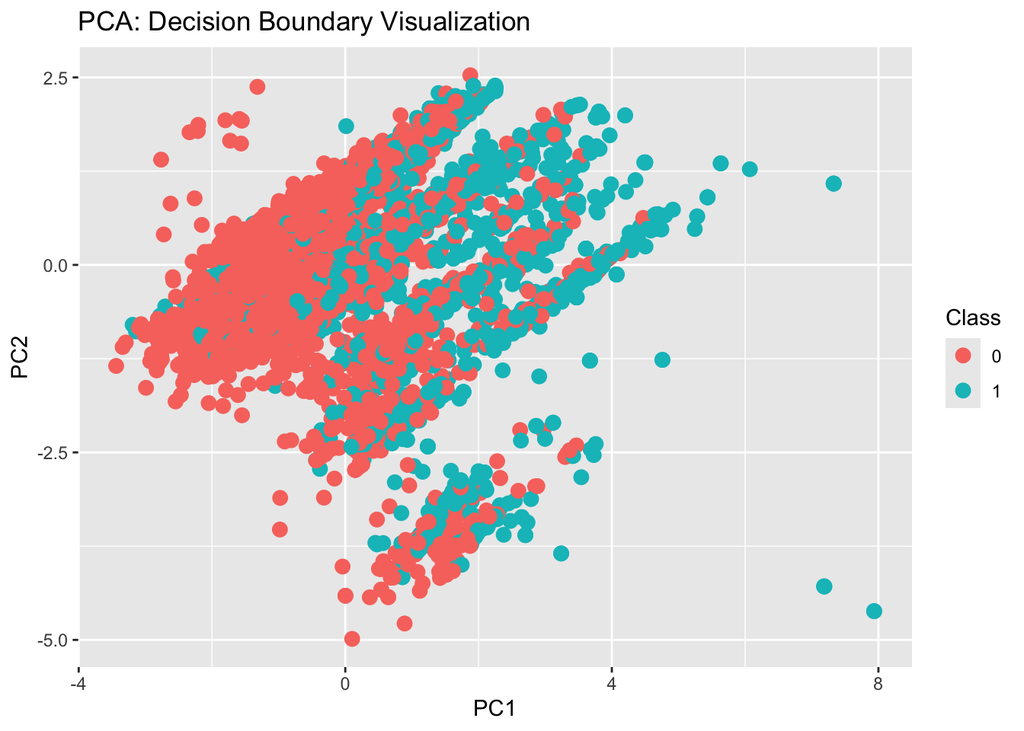

```r
library(ggplot2)
pca <- prcomp(X_train, center = TRUE, scale. = TRUE)
pca_data <- data.frame(PC1 = pca$x[, 1], PC2 = pca$x[, 2], Class = y_train)
ggplot(pca_data, aes(x = PC1, y = PC2, color = Class)) +
  geom_point(size = 3) +
  labs(title = "PCA: Decision Boundary Visualization")
```

As we can see we cannot decide if the boundary is linear or non-linear hence, lets make two models linear and non-linear SVM to check which one is a better fit.

### Tuning to find the best parameter values for C and Gamma for SVM non-linear

```r
# Load necessary libraries
library(e1071)
library(caret)

# Assuming you have already defined X_train, y_train, X_test, y_test

# Combine the training data into a data frame
train_data <- as.data.frame(cbind(X_train, y_train))

# Set up k-fold cross-validation
set.seed(42)
train_control <- trainControl(method = "cv", number = 5)

# Define the tuning grid for 'C' and 'sigma' (gamma)
tune_grid <- expand.grid(C = c( 0.1, 1, 10, 100),
                          sigma = c(0.5, 1))

# Train the SVM model using radial kernel with the tuning grid
svm_model <- train(y_train ~ ., data = train_data,
                   method = "svmRadial",
                   tuneGrid = tune_grid,
                   trControl = train_control)

# Print the results of the tuning
print(svm_model)
```

```
## Support Vector Machines with Radial Basis Function Kernel
##
## 8131 samples
##   39 predictor
##    2 classes: '0', '1'
##
## No pre-processing
## Resampling: Cross-Validated (5 fold)
## Summary of sample sizes: 6504, 6505, 6505, 6506, 6504
## Resampling results across tuning parameters:
##
##   C      sigma  Accuracy   Kappa
##     0.1  0.5    0.7152887  0.4135606
##     0.1  1.0    0.7103702  0.3989988
##     1.0  0.5    0.7653439  0.5245875
##     1.0  1.0    0.7691565  0.5316017
##    10.0  0.5    0.7864964  0.5679965
##    10.0  1.0    0.7775180  0.5503263
##   100.0  0.5    0.7925222  0.5808094
##   100.0  1.0    0.7809624  0.5579036
##
## Accuracy was used to select the optimal model using the largest value.
## The final values used for the model were sigma = 0.5 and C = 100.
```

```r
# Best model parameters
best_params <- svm_model$bestTune
cat("Best Parameters:\n")
```

```
## Best Parameters:
```

```r
print(best_params)
```

```
##   sigma   C
## 7   0.5 100
```

### Tuning to find the best parameter values for C for SVM linear

```r
# Load necessary libraries
library(e1071)
library(caret)

# Assuming you have already defined X_train, y_train, X_test, y_test

# Combine the training data into a data frame
train_data <- as.data.frame(cbind(X_train, y_train))

# Set up k-fold cross-validation
set.seed(42)
train_control <- trainControl(method = "cv", number = 5)

# Define the tuning grid for 'C' and 'sigma' (gamma)
tune_grid <- expand.grid(C = c( 0.1, 1, 10, 100))

# Train the SVM model using radial kernel with the tuning grid
svm_model <- train(y_train ~ ., data = train_data,
                   method = "svmLinear",
                   tuneGrid = tune_grid,
                   trControl = train_control)

# Print the results of the tuning
print(svm_model)
```

```
## Support Vector Machines with Linear Kernel
##
## 8131 samples
##   39 predictor
##    2 classes: '0', '1'
##
## No pre-processing
## Resampling: Cross-Validated (5 fold)
## Summary of sample sizes: 6504, 6505, 6505, 6506, 6504
## Resampling results across tuning parameters:
##
##   C      Accuracy   Kappa
##     0.1  0.7422242  0.4695042
##     1.0  0.7841613  0.5544567
##    10.0  0.8463913  0.6827210
##   100.0  0.9097293  0.8154933
##
## Accuracy was used to select the optimal model using the largest value.
## The final value used for the model was C = 100.
```

```r
# Best model parameters
best_params <- svm_model$bestTune
cat("Best Parameters:\n")
```

```
## Best Parameters:
```

```r
print(best_params)
```

```
##     C
## 4 100
```

```r
y_test
```

[output not shown]

[output cut: 60 more lines]

```r
# Load necessary libraries
library(e1071)
library(pROC)  # For ROC and AUC

# Assuming you have already defined X_train, y_train, X_test, y_test

# Combine the training data into a data frame
train_data <- as.data.frame(cbind(X_train, y_train))

# Fit the SVM model with linear kernel
svm_model <- svm(y_train ~ ., data = train_data, kernel = "linear", cost = 100, decision.values = TRUE)

# Step 1: Make predictions on the test set
predictions <- predict(svm_model, newdata = as.data.frame(X_test))

# Step 2: Create confusion matrix
confusion_matrix <- table(Predicted = predictions, Actual = y_test)
cat("Confusion Matrix:\n")
```

```
## Confusion Matrix:
```

```r
print(confusion_matrix)
```

```
##          Actual
## Predicted    0    1
##         0 1463  209
##         1    9 1028
```

```r
# Step 3: Calculate accuracy
accuracy <- sum(diag(confusion_matrix)) / sum(confusion_matrix)
cat("Accuracy:", accuracy, "\n")
```

```
## Accuracy: 0.9195275
```

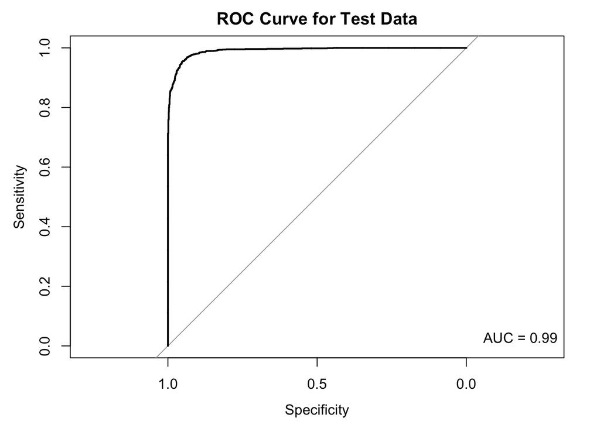

```r
# Step 4: Get decision values for ROC curve
fitted <- attributes(predict(svm_model, newdata = as.data.frame(X_test), decision.values = TRUE))$decision.values

# Step 5: Generate ROC plot for the test set
roc_curve <- roc(y_test, -fitted)  # Note: Use negative for class labeling

# Plot the ROC curve
plot(roc_curve, main = "ROC Curve for Test Data")
# Add AUC to the plot
auc_value <- auc(roc_curve)
legend("bottomright", legend = paste("AUC =", round(auc_value, 2)), bty = "n")
```

#### Feature importance for the model

```r
# Assuming you have already trained your SVM model (svm_model) using e1071

# Get coefficients from the SVM model
coefficients <- as.vector(svm_model$coefs) %*% svm_model$SV

# Get the intercept term
intercept <- svm_model$rho

# Combine coefficients and intercept into a single vector
all_coefficients <- c(intercept, coefficients)

# Print coefficients
cat("Coefficients (including intercept):\n")
```

```
## Coefficients (including intercept):
```

```r
print(all_coefficients)
```

```
##  [1]  3.757804e+01 -1.105737e-02 -2.657088e+02 -4.791294e-03  8.665071e+00
##  [6] -2.317642e-03  2.440945e-02  2.389030e-03  5.160932e-03  1.677609e-03
## [11]  2.567363e-03  3.369154e-04  6.187170e-03 -3.992035e-04  8.476055e-04
## [16] -1.333158e-02 -1.325342e-01  1.314938e-02  9.537075e-03  1.275400e-02
## [21]  3.183417e-05  1.100717e-03 -2.853351e-05 -3.360304e-03  5.361099e-03
## [26]  2.410155e-03 -9.017911e-04  2.870593e-02  4.278036e-03  1.717393e-03
## [31] -1.818900e-03 -5.158708e-03 -8.358235e-04 -4.410840e-03  5.100021e-04
## [36]  2.135145e-02  1.016372e-03 -2.968885e-03 -1.750337e-03 -5.696341e-03
```

```r
# Check the number of coefficients
num_coefficients <- length(all_coefficients)
cat("Number of Coefficients (including intercept):", num_coefficients, "\n")
```

```
## Number of Coefficients (including intercept): 40
```

```r
# Get feature names
feature_names <- colnames(X_train)

# Create a named vector for coefficients with feature names
named_coefficients <- setNames(coefficients, feature_names)

# Print named coefficients
cat("Feature Coefficients:\n")
```

```
## Feature Coefficients:
```

```r
print(named_coefficients)
```

```
##           Rating   Reviews         Size    Price Content.Rating Last.Updated
## [1,] -0.01105737 -265.7088 -0.004791294 8.665071   -0.002317642   0.02440945
##      catART_AND_DESIGN catAUTO_AND_VEHICLES   catBEAUTY catBOOKS_AND_REFERENCE
## [1,]        0.00238903          0.005160932 0.001677609            0.002567363
##       catBUSINESS  catCOMICS catCOMMUNICATION    catDATING catEDUCATION
## [1,] 0.0003369154 0.00618717    -0.0003992035 0.0008476055  -0.01333158
##      catENTERTAINMENT  catEVENTS   catFAMILY catFINANCE catFOOD_AND_DRINK
## [1,]       -0.1325342 0.01314938 0.009537075   0.012754      3.183417e-05
##          catGAME catHEALTH_AND_FITNESS catHOUSE_AND_HOME catLIBRARIES_AND_DEMO
## [1,] 0.001100717         -2.853351e-05      -0.003360304           0.005361099
##      catLIFESTYLE catMAPS_AND_NAVIGATION catMEDICAL catNEWS_AND_MAGAZINES
## [1,]  0.002410155          -0.0009017911 0.02870593           0.004278036
##      catPARENTING catPERSONALIZATION catPHOTOGRAPHY catPRODUCTIVITY catSHOPPING
## [1,]  0.001717393         -0.0018189   -0.005158708   -0.0008358235 -0.00441084
##         catSOCIAL  catSPORTS    catTOOLS catTRAVEL_AND_LOCAL catVIDEO_PLAYERS
## [1,] 0.0005100021 0.02135145 0.001016372        -0.002968885     -0.001750337
##        catWEATHER
## [1,] -0.005696341
## attr(,"names")
##  [1] "Rating"                 "Reviews"                "Size"
##  [4] "Price"                  "Content.Rating"         "Last.Updated"
##  [7] "catART_AND_DESIGN"      "catAUTO_AND_VEHICLES"   "catBEAUTY"
## [10] "catBOOKS_AND_REFERENCE" "catBUSINESS"            "catCOMICS"
## [13] "catCOMMUNICATION"       "catDATING"              "catEDUCATION"
## [16] "catENTERTAINMENT"       "catEVENTS"              "catFAMILY"
## [19] "catFINANCE"             "catFOOD_AND_DRINK"      "catGAME"
## [22] "catHEALTH_AND_FITNESS"  "catHOUSE_AND_HOME"      "catLIBRARIES_AND_DEMO"
## [25] "catLIFESTYLE"           "catMAPS_AND_NAVIGATION" "catMEDICAL"
## [28] "catNEWS_AND_MAGAZINES"  "catPARENTING"           "catPERSONALIZATION"
## [31] "catPHOTOGRAPHY"         "catPRODUCTIVITY"        "catSHOPPING"
## [34] "catSOCIAL"              "catSPORTS"              "catTOOLS"
## [37] "catTRAVEL_AND_LOCAL"    "catVIDEO_PLAYERS"       "catWEATHER"
```

```r
# Sort coefficients by absolute value for feature importance
sorted_coefficients <- sort(abs(named_coefficients), decreasing = TRUE)

# Print sorted feature importance
cat("Sorted Feature Importance:\n")
```

```
## Sorted Feature Importance:
```

```r
print(sorted_coefficients)
```

```
##                Reviews                  Price       catENTERTAINMENT
##           2.657088e+02           8.665071e+00           1.325342e-01
##             catMEDICAL           Last.Updated              catSPORTS
##           2.870593e-02           2.440945e-02           2.135145e-02
##           catEDUCATION              catEVENTS             catFINANCE
##           1.333158e-02           1.314938e-02           1.275400e-02
##                 Rating              catFAMILY              catCOMICS
##           1.105737e-02           9.537075e-03           6.187170e-03
##             catWEATHER  catLIBRARIES_AND_DEMO   catAUTO_AND_VEHICLES
##           5.696341e-03           5.361099e-03           5.160932e-03
##         catPHOTOGRAPHY                   Size            catSHOPPING
##           5.158708e-03           4.791294e-03           4.410840e-03
##  catNEWS_AND_MAGAZINES      catHOUSE_AND_HOME    catTRAVEL_AND_LOCAL
##           4.278036e-03           3.360304e-03           2.968885e-03
## catBOOKS_AND_REFERENCE           catLIFESTYLE      catART_AND_DESIGN
##           2.567363e-03           2.410155e-03           2.389030e-03
##         Content.Rating     catPERSONALIZATION       catVIDEO_PLAYERS
##           2.317642e-03           1.818900e-03           1.750337e-03
##           catPARENTING              catBEAUTY                catGAME
##           1.717393e-03           1.677609e-03           1.100717e-03
##               catTOOLS catMAPS_AND_NAVIGATION              catDATING
##           1.016372e-03           9.017911e-04           8.476055e-04
##        catPRODUCTIVITY              catSOCIAL       catCOMMUNICATION
##           8.358235e-04           5.100021e-04           3.992035e-04
##            catBUSINESS      catFOOD_AND_DRINK  catHEALTH_AND_FITNESS
##           3.369154e-04           3.183417e-05           2.853351e-05
```

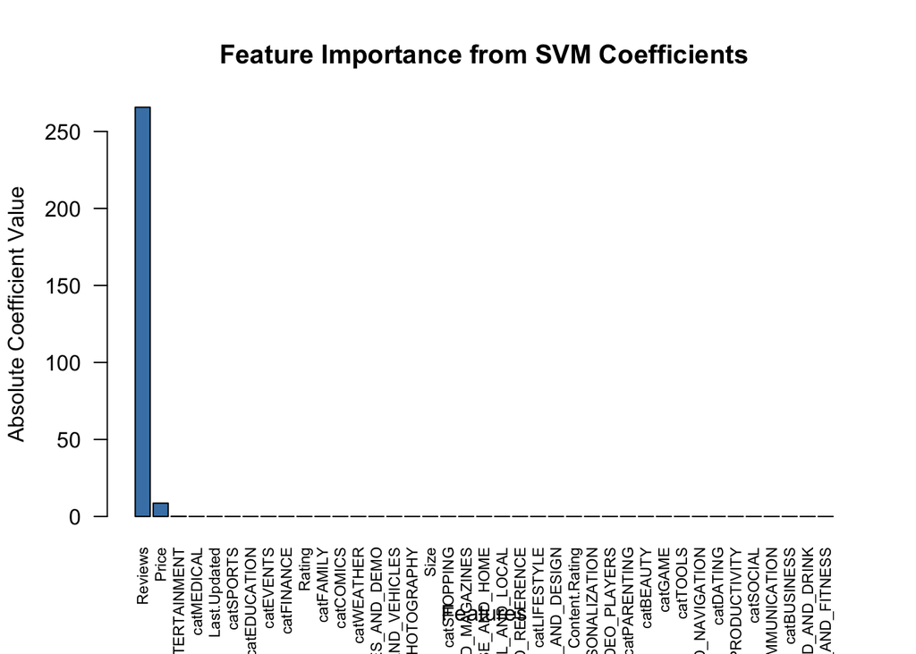

```r
# Optional: Visualize feature importance
barplot(
  sorted_coefficients,
  main = "Feature Importance from SVM Coefficients",
  xlab = "Features",
  ylab = "Absolute Coefficient Value",
  col = "steelblue",
  las = 2,
  cex.names = 0.7  # Adjust name size if necessary
)
```